# Getting Started With R and RStudio

Ryan Wallis

19/06/2024

## Installing R

R is the coding language - this is what we will actually write code in.

R can be downloaded from the official website - https://cran.r-project.org/

You must select the appropraite version for your opperating system.

**Windows**: Select the “base” option and follow the installation wizard with all default settings.

**MAC**: Select the most up to date version for your machine.

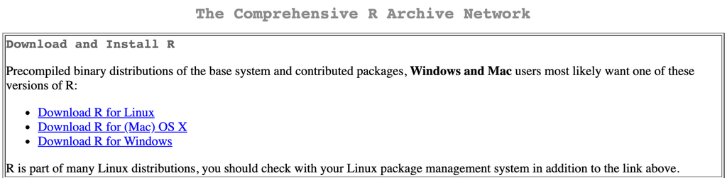

## Installing RStudio

RStudio is an integrated development environment (IDE) an application that provides a user-friendly interface for working with R.

RStudio is downloaded from the official website (now called posit) - https://posit.co/download/rstudio-desktop/

Your operating system should be automatically detected - download this and follow the wizard

## RStudio First Look

Opening R Studio will drop you in a page like this (your colour scheme will be different!)

There are four main parts of RStudio (see image) we will discuss these each in turn

[figure not shown]

## The Console

This is where code is executed - its is the interface for the computer reading the code we have written and then performing the tasks.

Scripts can be written directly in the console (next to the > symbol) and run by pressing enter

In this guide the code we have writen is in the grey boxes and the result (which appears in the console) are in white boxes with ## bbefore

In its most basic form R can be used as a calculator

```r
2+2
```

```
## [1] 4
```

We can also store data as objects by using the assignment operator <-

```r
Data <- 2+2
```

In this case the value 4 is not returned because we have not asked for the result to be displayed. We have just asked it to be stored as an object called data.

If we then “call” Data we will be shown its value

```r
Data
```

```
## [1] 4
```

Objects act as the values that we have assigned to them. So we can perform calculations with them

```r
Data + Data
```

```
## [1] 8
```

And mix and match

```r
Data + 5
```

```
## [1] 9
```

Importantly - the names of objects is case specific so if we try and call data it wont work and we will get an error

```r
DATA
```

```
## Error in eval(expr, envir, enclos): object 'DATA' not found
```

In general we only occasionally write code in the console and when we do we then execute it immediatley. But this is not useful for builing up complex and reproducible analysis as the code is lost once it is run.

Therefore, we write our code as scripts in the top left box where code can be saved and reused.

## Scripts

New scripts can be created by going to file > new file > R script (control+shift+N)

Scripts are sent to the console for execution either by using control+shift+enter to run all or control+enter to run the current line where your cursor is. This can also be done from the run button (red box)

It is important to remember that scripts are run from top to bottom and all called results will be output in the console.

[figure not shown]

So in the example:

Comments can be added to your script using hashtags (#) this will make the console ignore these lines.

```r
2 + 1
```

```
## [1] 3
```

```r
Data <- 2 + 2

Double_Data <- Data + Data

Data <- 5

Data
```

```
## [1] 5
```

```r
Double_Data
```

```
## [1] 8
```

```r
# This is an example comment
```

We will return to make some more complex scripts later - but for now, it is only required to remember scripts allow us to send sets of instricutions to the console in a specific order

## The Environment

This is where your objects and their values are stored.

After running the script above we now have our two objects - which are stored under the “values” tab

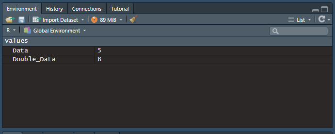

We also have an indication here of how much memory our computer is currently using (disk symbol) - my work laptop is rubbish so its almost full!

The brush icon allows us to clear all objects that are stored. Its often useful to do this before running a script to make sure it runs from start to finish without any problems and is able to do so without any objects that might have been saved through the console or in another script in the same R session

## R Projects and the Working Directory

Creating an R Project 1. Open RStudio. 2. Create a New Project: 3. Go to File > New Project. 4. Choose New Directory to create a new folder or Existing Directory to use an existing folder.

### Working Directory

The working directory is the folder where R reads and saves files by default. You must be in the right place or R wont be able to see your files. When using a project it is automatically set to the file where the project is saved.

### Checking the Working Directory

Use the getwd() function to check the current working directory.

```r
getwd()
```

```
## [1] "C:/Users/hmy922/OneDrive - Queen Mary, University of London/Phenotypic Screening Facility/Code Repository/Github Repositories/R_Markdown_Guides_Management/R"
```

### Setting the Working Directory

You can set the working directory using the setwd() function or through RStudio’s interface.

```r
setwd("path/to/your/directory")
```

```
## Error in setwd("path/to/your/directory"): cannot change working directory
```

## Types of Data and Objects

### Objects

We have already seen that values can be stored as objects in R. The name of objects is important and there are certain rules that R imposes. Attempting to use the following in object names will throw an error:

1. Numbers at the Start

```r
1st_variable <- 10  # Invalid name
variable1 <- 10     # Valid name
```

```
## Error: <text>:1:2: unexpected symbol
## 1: 1st_variable
##      ^
```

2. Special Characters

Avoid using special characters such as !, @, #, $, %, ^, &, *, (, ), -, +, =, {, }, [, ], :, ;, “, ’, <, >, ,, ?, /, |, . The only special characters allowed are underscores (_) and periods (.), but periods cannot be used at the beginning of an object name unless the name starts with . followed by a letter

```r
total-sales <- 1000  # Invalid name due to hyphen
total.sales <- 1000  # Valid name
_total_sales <- 1000  # Invalid name (underscore at the start)
total_sales_ <- 1000  # Valid name
```

```
## Error: <text>:3:2: unexpected symbol
## 2: total.sales <- 1000  # Valid name
## 3: _total_sales
##     ^
```

3. Reserved Words R has reserved words that cannot be used as object names. These include control flow elements, logical constants, and operators.

```r
if <- 10       # Invalid name
else <- 20     # Invalid name
TRUE <- 30     # Invalid name
function <- 40 # Invalid name
```

```
## Error: <text>:1:4: unexpected assignment
## 1: if <-
##        ^
```

3. Object names cannot contain spaces. Use underscores or periods instead to separate words.

```r
my variable <- 100  # Invalid name
my_variable <- 100  # Valid name
my.variable <- 100  # Valid name
```

```
## Error: <text>:1:4: unexpected symbol
## 1: my variable
##        ^
```

### Vectors

Vectors are the most basic data type in R. They are sequences of elements of the same type. You can create a vector using the c() function.

These can be in the form of numeric data (numbers) words (called character strings in R and bound within ” “) or boolean values (TRUE or FALSE)

```r
# Numeric vector
numeric_vector <- c(1, 2, 3, 4, 5)
numeric_vector
```

```
## [1] 1 2 3 4 5
```

```r
# Character vector
character_vector <- c("apple", "banana", "cherry")
character_vector
```

```
## [1] "apple"  "banana" "cherry"
```

```r
# Logical vector
logical_vector <- c(TRUE, FALSE, TRUE)
logical_vector
```

```
## [1]  TRUE FALSE  TRUE
```

### Factors

Factors are used to handle categorical data. They are stored as integers with corresponding levels. They are often used when sorting data.

```r
# Creating a factor
fruits <- factor(c("apple", "banana", "cherry", "banana", "cherry"))
fruits
```

```
## [1] apple  banana cherry banana cherry
## Levels: apple banana cherry
```

```r
levels(fruits)
```

```
## [1] "apple"  "banana" "cherry"
```

### Matrices

Matrices are two-dimensional arrays that hold elements of the same type. You can create a matrix using the matrix() function.

```r
# Creating a matrix
matrix_data <- matrix(1:9, nrow = 3, ncol = 3)
matrix_data
```

```
##      [,1] [,2] [,3]
## [1,]    1    4    7
## [2,]    2    5    8
## [3,]    3    6    9
```

### Data Frames

Data frames are the most common way to store data in R. They are like matrices but can hold different types of data in each column.

```r
# Creating a data frame
data_frame <- data.frame(
  Name = c("John", "Paul", "George", "Ringo"),
  Age = c(30, 40, 35, 50),
  Score = c(85, 90, 88, 75)
)
data_frame
```

```
##     Name Age Score
## 1   John  30    85
## 2   Paul  40    90
## 3 George  35    88
## 4  Ringo  50    75
```

### Lists

Lists are versatile and can contain elements of different types, including other lists, vectors, and data frames.

```r
# Creating a list
my_list <- list(
  name = "Ryan",
  age = 29,
  scores = c(85, 90, 88),
  details = data_frame
)
my_list
```

```
## $name
## [1] "Ryan"
##
## $age
## [1] 29
##
## $scores
## [1] 85 90 88
##
## $details
##     Name Age Score
## 1   John  30    85
## 2   Paul  40    90
## 3 George  35    88
## 4  Ringo  50    75
```

## Exploring and Manipulating Data

These are very basic operations to explore data

```r
# Checking the structure of an object
str(data_frame)
```

```
## 'data.frame':    4 obs. of  3 variables:
##  $ Name : chr  "John" "Paul" "George" "Ringo"
##  $ Age  : num  30 40 35 50
##  $ Score: num  85 90 88 75
```

```r
# Viewing the first few rows of a data frame
head(data_frame)
```

```
##     Name Age Score
## 1   John  30    85
## 2   Paul  40    90
## 3 George  35    88
## 4  Ringo  50    75
```

```r
# Summary statistics for a data frame
summary(data_frame)
```

```
##      Name                Age            Score
##  Length:4           Min.   :30.00   Min.   :75.0
##  Class :character   1st Qu.:33.75   1st Qu.:82.5
##  Mode  :character   Median :37.50   Median :86.5
##                     Mean   :38.75   Mean   :84.5
##                     3rd Qu.:42.50   3rd Qu.:88.5
##                     Max.   :50.00   Max.   :90.0
```

## Subsetting Data

There are often many ways to achieve the same thing in R and similar syntax is used to perform operations on different data types.

Square brackets [] are used to subset a list to pull out values at a specific index position (R starts at 1 unlike python which starts at 0!)

Square brackets with a comma [ , ] allows you to select specific parts of a data frame or matrix. Left of the comma indicates rows and right columns. If left blank all rows/columns are selected

Using a dollar sign ($) allows you to select columns by their names. In general it is useful if your column names don’t have spaces and use underscores (_) or camel case (ColumnName). However, if columns do have spaces they can be looked for using backticks (`` `column name` `` ) **Note** these are not apostrophes!

```r
# Subsetting a vector
numeric_vector[1:3]
```

```
## [1] 1 2 3
```

```r
# Subsetting a data frame
data_frame[1:2, ]
```

```
##   Name Age Score
## 1 John  30    85
## 2 Paul  40    90
```

```r
# Subsetting a list
my_list$scores
```

```
## [1] 85 90 88
```

## Libararies

R has a vast collection of packages (also known as libraries) that extend its basic functionality. These packages provide additional functions, data, and documentation to help you perform specific tasks more efficiently.

Often functions in base R can be performed with more control using a package. As above there are often many ways to achieve the same thing in R.

```r
# Installing a package
install.packages("ggplot2")
```

### Loading Packages

After installing a package, you need to load it into your R session using the library() function.

```r
# Loading a package
library(ggplot2)
```

### Common Packages

Here are some commonly used packages in R:

ggplot2: For advanced data visualization.

dplyr: For data manipulation. tidyr: For data tidying. readr: For reading data.

This is by far the most widely used package for making graphs. This is a very basic example but we have other guides for more details on making elegant plots in R.

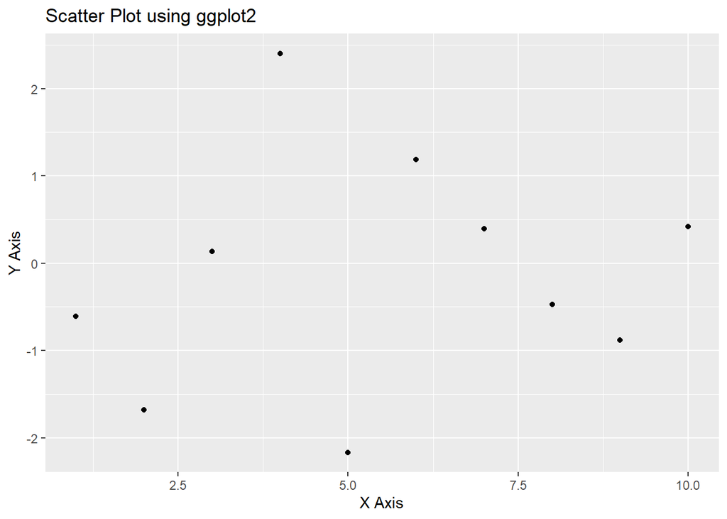

```r
# Loading the ggplot2 package
library(ggplot2)
# Sample data
data <- data.frame(x = 1:10, y = rnorm(10))

# Creating a scatter plot using ggplot2
ggplot(data, aes(x = x, y = y)) +
  geom_point() +
  ggtitle("Scatter Plot using ggplot2") +
  xlab("X Axis") +
  ylab("Y Axis")
```

## Importing Data

Importing data is a fundamental task in data analysis. R can read data from various sources, such as CSV and Excel files.

### Reading CSV Files

The read.csv() function is commonly used to read CSV files.

```r
# Reading a CSV file
data <- read.csv("path/to/your/data.csv")
```

```
## Error in file(file, "rt"): cannot open the connection
```

```r
head(data)
```

[output not shown]

### Reading Excel Files

To read Excel files, you need the readxl package.

```r
# Installing the readxl package
install.packages("readxl")

# Loading the readxl package
library(readxl)

# Reading an Excel file
data <- read_excel("path/to/your/data.xlsx", sheet = 1)
head(data)
```

## Saving Work

### Saving Data Frames

You can save data frames to various file formats.

```r
# Saving a data frame to a CSV file
write.csv(data, "path/to/your/data.csv", row.names = FALSE)
```

```
## Error in file(file, ifelse(append, "a", "w")): cannot open the connection
```

```r
# Saving a data frame to an Excel file
library(writexl)
```

```
## Error in library(writexl): there is no package called 'writexl'
```

```r
write_xlsx(data, "path/to/your/data.xlsx")
```

```
## Error in write_xlsx(data, "path/to/your/data.xlsx"): could not find function "write_xlsx"
```

### Saving R Scripts

You can save your R scripts directly from RStudio.

Go to File > Save As…. Choose a location and name for your script. Click Save.

## Summary

In this guide we cover getting set up in R and R studio

We have further dedicated guides on the facility GitHub and Teams Hub.

These include how reading in your data, tidying it up and making plots.

Key things to remember:

1. Someone has probably had the same problem as you - Google is your friend!
2. There are many ways to achieve the same things in R - but in general try and not mix and match solutions!